# Batch48-PHD ----------Sales Forecasting of Retail Clothing Product Categories using Regression Ananlysis----------

Problem Description: Building a framework that provides monthly forecasts of the 12 months (ie., from Jan 2016 to Dec 2106) for "Womenclothing" product category with influencing factors of the sales such as holiday events, weather changes, Macroeconomic factors etc using the Regression model.

#### How this Business problem is converted into a Machine Learning problem and how it will help the business?

Sales planning is significant for any Retail stores. Forecasting of retail sales helps retailer to take necessary measures to plan their budgets or investments in a period (monthly, yearly). The problem with them is they need to be aware of future sales and accordingly they can update the stocks of different categgories clothing to gain more sales and profits. Sometimes,Stock is not immediately available, customers may not have the luxury or patience to wait and customer might dissatisfied so this translates into lost sales and low customer satisfaction.So, The good news is that powerful Machine Learning (ML) algorithm can help to forecast sales of different category clothng product for next few years.

```python
#setting working directory
import os
os.chdir("C:\\Users\\RK\\Desktop\\ML_2338_PHD")
```

```python
os.getcwd()
```

```
'C:\\Users\\RK\\Desktop\\ML_2338_PHD'
```

# ------------------- Importing Required Pacakges -------------------

```python
import os
import numpy as np
import pandas as pd
import matplotlib.pyplot as plt
import seaborn as sns
from matplotlib import style
from sklearn import preprocessing
from sklearn import feature_selection
from sklearn.linear_model import LinearRegression
from sklearn.feature_selection import SelectKBest
from sklearn.feature_selection import f_regression
from statsmodels.formula.api import OLS
from sklearn.svm import SVR
from sklearn.model_selection import GridSearchCV, StratifiedKFold
from statsmodels.stats.outliers_influence import variance_inflation_factor
from sklearn.ensemble import RandomForestRegressor
from sklearn.linear_model import Ridge,Lasso
import xgboost as xgb
import warnings
warnings.filterwarnings("ignore")
```

# ---------------- Loading the Files ------------------

Reading all the given files Train.csv, Events_HolidaysData.xlsx, MacroEconomicData.xlsx & WeatherDataNew-1549298254132.xlsx into pandas using pd.read() function.

```python
Train_Data = pd.read_csv("Train.csv")
EventHolidays_Data = pd.read_excel("Events_HolidaysData.xlsx")
Macroeconomic_Data = pd.read_excel("MacroEconomicData.xlsx")
Weather_Data_xlsx = pd.ExcelFile("WeatherDataNew-1549298254132.xlsx")
```

# --------------- Understanding the Data --------------------

Understanding the Data of all the given datasets using top 5 and bottom 5 rows of data using head() and tail() function. Moreover also looking at count values of column and also datatype of each columns.

# 1) Train Sales Data

```python
#Checking top 5 rows of Train Data
Train_Data.head(5)
```

|  | Year | Month | ProductCategory | Sales(In ThousandDollars) |
| --- | --- | --- | --- | --- |
| 0 | 2009 | 1 | WomenClothing | 1755.0 |
| 1 | 2009 | 1 | MenClothing | 524.0 |
| 2 | 2009 | 1 | OtherClothing | 936.0 |
| 3 | 2009 | 2 | WomenClothing | 1729.0 |
| 4 | 2009 | 2 | MenClothing | 496.0 |

```python
#Checking bottom 5 rows of Train Data
Train_Data.tail(5)
```

|  | Year | Month | ProductCategory | Sales(In ThousandDollars) |
| --- | --- | --- | --- | --- |
| 247 | 2015 | 11 | MenClothing | 643.0 |
| 248 | 2015 | 11 | OtherClothing | 1478.0 |
| 249 | 2015 | 12 | WomenClothing | 5874.0 |
| 250 | 2015 | 12 | MenClothing | 967.0 |
| 251 | 2015 | 12 | OtherClothing | 1680.0 |

```python
#Checking the Dimension
Train_Data.shape
```

```
(252, 4)
```

```python
#Checking the datatypes
Train_Data.dtypes
```

```
Year                           int64
Month                          int64
ProductCategory               object
Sales(In ThousandDollars)    float64
dtype: object
```

```python
#As ProdcutCategory is categorical so checking the count value of its 3 category
Train_Data['ProductCategory'].value_counts()
```

```
MenClothing      84
WomenClothing    84
OtherClothing    84
Name: ProductCategory, dtype: int64
```

# 2) Event_Holidays Data

```python
#Checking the datatypes
print("Datatypes of each columns:")
print(EventHolidays_Data.dtypes)
```

```
Datatypes of each columns:
Year                    int64
MonthDate      datetime64[ns]
Event                  object
DayCategory            object
dtype: object
```

```python
#Checking top 5 rows
print("The first 5 rows from the table:")
EventHolidays_Data.head()
```

```
The first 5 rows from the table:
```

|  | Year | MonthDate | Event | DayCategory |
| --- | --- | --- | --- | --- |
| 0 | 2009 | 2001-01-01 | New Year's Day | Federal Holiday |
| 1 | 2009 | 2019-01-01 | Martin Luther King Jr. Day | Federal Holiday |
| 2 | 2009 | 2014-02-01 | Valentine's Day | Event |
| 3 | 2009 | 2016-02-01 | Presidents' Day | Federal Holiday |
| 4 | 2009 | 2012-04-01 | Easter Sunday | Event |

```python
#Checking the bottom 5 rows
print("The bottom 5 rows from the table:")
EventHolidays_Data.tail()
```

```
The bottom 5 rows from the table:
```

|  | Year | MonthDate | Event | DayCategory |
| --- | --- | --- | --- | --- |
| 145 | 2016 | 2024-11-01 | Thanksgiving Day | Federal Holiday |
| 146 | 2016 | 2024-12-01 | Christmas Eve | Event |
| 147 | 2016 | 2025-12-01 | Christmas Day | Federal Holiday |
| 148 | 2016 | 2026-12-01 | 'Christmas Day' observed | Federal Holiday |
| 149 | 2016 | 1931-12-01 | New Year's Eve | Event |

```python
#Checking for  Daycategory column and their counnt values
print("The categories and their count in 'DayCategory' column:")
print(EventHolidays_Data.DayCategory.value_counts())
```

```
The categories and their count in 'DayCategory' column:
Federal Holiday    88
Event              62
Name: DayCategory, dtype: int64
```

```python
#Checking all the event columns count value
print(EventHolidays_Data.Event.value_counts())
```

```
Father's Day                   8
Thanksgiving Day               8
Valentine's Day                8
Veterans Day                   8
Christmas Eve                  8
New Year's Eve                 8
Columbus Day (Most regions)    8
Mother's Day                   8
Easter Sunday                  8
Presidents' Day                8
Halloween                      8
Memorial Day                   8
Independence Day               8
Christmas Day                  8
Labor Day                      8
Martin Luther King Jr. Day     8
New Year's Day                 8
'Christmas Day' observed       3
'Independence Day' observed    3
Thomas Jefferson's Birthday    3
Election Day                   2
'New Year's Day' observed      2
Day After Christmas Day        1
Name: Event, dtype: int64
```

# 3) MacroEconomic Data

```python
#checking top 5 rows of data
print("The first 5 rows from the table :")
Macroeconomic_Data.head()
```

```
The first 5 rows from the table :
```

|  | Year-Month | Monthly Nominal GDP Index (inMillion$) | Monthly Real GDP Index (inMillion$) | CPI | PartyInPower | unemployment rate | CommercialBankInterestRateonCreditCardPlans | Finance Rate on Personal Loans at Commercial Banks, 24 Month Loan | Earnings or wages in dollars per hour | AdvertisingExpenses (in Thousand Dollars) | Cotton Monthly Price - US cents per Pound(lbs) | Change(in%) | Average upland planted(million acres) | Average upland harvested(million acres) | yieldperharvested acre | Production (in 480-lb netweright in million bales) | Mill use (in 480-lb netweright in million bales) | Exports |
| --- | --- | --- | --- | --- | --- | --- | --- | --- | --- | --- | --- | --- | --- | --- | --- | --- | --- | --- |
| 0 | 2009 - Jan | 14421.752895 | 14407.053343 | 233.402 | Democrats | 7.8 | 12.03 | 11.44 | 22.05 | 137 | 57.70 | 4.02 | 9.296 | 7.559 | 799 | 12.589 | 4.17 | 11.550 |
| 1 | 2009 - Feb | 14389.200466 | 14366.176571 | 234.663 | Democrats | 8.3 | 12.97 | 11.05 | 22.22 | 200 | 55.21 | -4.32 | 9.296 | 7.559 | 799 | 12.589 | 3.87 | 11.100 |
| 2 | 2009 - Mar | 14340.701639 | 14351.786822 | 235.067 | Democrats | 8.7 | 12.97 | 11.05 | 22.22 | ? | 51.50 | -6.72 | 9.296 | 7.559 | 799 | 12.589 | 3.72 | 11.650 |
| 3 | 2009 - Apr | 14326.815525 | 14351.601731 | 235.582 | Democrats | 9.0 | 12.97 | 11.05 | 22.13 | 214 | 56.78 | 10.25 | 9.296 | 7.559 | 787 | 12.400 | 3.62 | 12.225 |
| 4 | 2009 - May | 14345.904809 | 14368.123959 | 235.975 | Democrats | 9.4 | 13.32 | 11.25 | 22.04 | ? | 61.95 | 9.11 | 9.297 | 7.400 | 803 | 12.384 | 3.52 | 12.300 |

```python
#Checking for last bottom 5 rows in data
print("The bottom 5 rows from the table :")
Macroeconomic_Data.tail()
```

```
The bottom 5 rows from the table :
```

|  | Year-Month | Monthly Nominal GDP Index (inMillion$) | Monthly Real GDP Index (inMillion$) | CPI | PartyInPower | unemployment rate | CommercialBankInterestRateonCreditCardPlans | Finance Rate on Personal Loans at Commercial Banks, 24 Month Loan | Earnings or wages in dollars per hour | AdvertisingExpenses (in Thousand Dollars) | Cotton Monthly Price - US cents per Pound(lbs) | Change(in%) | Average upland planted(million acres) | Average upland harvested(million acres) | yieldperharvested acre | Production (in 480-lb netweright in million bales) | Mill use (in 480-lb netweright in million bales) | Exports |
| --- | --- | --- | --- | --- | --- | --- | --- | --- | --- | --- | --- | --- | --- | --- | --- | --- | --- | --- |
| 91 | 2016 - Aug | 18741.599947 | 16797.206610 | 264.160 | Democrats | 4.9 | 12.51 | 9.64 | 25.52 | ? | 80.26 | -0.99 | 9.824 | 9.340 | 787 | 15.314 | 3.575 | 10.950 |
| 92 | 2016 - Sep | 18840.309646 | 16852.562745 | 264.602 | Democrats | 4.9 | 12.51 | 9.64 | 25.74 | ? | 77.86 | -2.99 | 9.950 | 9.464 | 790 | 15.580 | 3.475 | 10.950 |
| 93 | 2016 - Oct | 18740.780023 | 16725.460098 | 264.738 | Democrats | 4.8 | 12.51 | 9.64 | 26.04 | ? | 78.52 | 0.85 | 9.950 | 9.464 | 785 | 15.472 | 3.475 | 11.425 |
| 94 | 2016 - Nov | 18960.461568 | 16910.896330 | 265.203 | Democrats | 4.6 | 12.41 | 9.45 | 25.87 | ? | 78.92 | 0.51 | 9.950 | 9.464 | 791 | 15.600 | 3.475 | 11.425 |
| 95 | 2016 - Dec | 19015.393408 | 16918.050624 | 265.421 | Democrats | 4.7 | 12.41 | 9.45 | 25.90 | ? | 79.50 | 0.73 | 9.950 | 9.464 | 810 | 15.962 | 3.275 | 11.600 |

```python
#Checking the datatypes of all the coulmns in data
print("Datatypes of each columns :")
print(Macroeconomic_Data.dtypes)
```

```
Datatypes of each columns :
Year-Month                                                            object
Monthly Nominal GDP Index (inMillion$)                               float64
Monthly Real GDP Index (inMillion$)                                  float64
CPI                                                                  float64
PartyInPower                                                          object
unemployment rate                                                    float64
CommercialBankInterestRateonCreditCardPlans                          float64
Finance Rate on Personal Loans at Commercial Banks, 24 Month Loan    float64
Earnings or wages  in dollars per hour                               float64
AdvertisingExpenses (in Thousand Dollars)                             object
Cotton Monthly Price - US cents per Pound(lbs)                       float64
Change(in%)                                                          float64
Average upland planted(million acres)                                float64
Average upland harvested(million acres)                              float64
yieldperharvested acre                                                 int64
Production (in  480-lb netweright in million bales)                  float64
Mill use  (in  480-lb netweright in million bales)                   float64
Exports                                                              float64
dtype: object
```

```python
# Printing the statistics of the macro economic table
Macroeconomic_Data.describe(include = 'all')
```

|  | Year-Month | Monthly Nominal GDP Index (inMillion$) | Monthly Real GDP Index (inMillion$) | CPI | PartyInPower | unemployment rate | CommercialBankInterestRateonCreditCardPlans | Finance Rate on Personal Loans at Commercial Banks, 24 Month Loan | Earnings or wages in dollars per hour | AdvertisingExpenses (in Thousand Dollars) | Cotton Monthly Price - US cents per Pound(lbs) | Change(in%) | Average upland planted(million acres) | Average upland harvested(million acres) | yieldperharvested acre | Production (in 480-lb netweright in million bales) | Mill use (in 480-lb netweright in million bales) | Exports |
| --- | --- | --- | --- | --- | --- | --- | --- | --- | --- | --- | --- | --- | --- | --- | --- | --- | --- | --- |
| count | 96 | 96.000000 | 96.000000 | 96.000000 | 96 | 96.000000 | 96.000000 | 96.000000 | 96.000000 | 96 | 96.000000 | 96.000000 | 96.000000 | 96.000000 | 96.000000 | 96.000000 | 96.000000 | 96.000000 |
| unique | 96 | NaN | NaN | NaN | 1 | NaN | NaN | NaN | NaN | 12 | NaN | NaN | NaN | NaN | NaN | NaN | NaN | NaN |
| top | 2011 - Aug | NaN | NaN | NaN | Democrats | NaN | NaN | NaN | NaN | ? | NaN | NaN | NaN | NaN | NaN | NaN | NaN | NaN |
| freq | 1 | NaN | NaN | NaN | 96 | NaN | NaN | NaN | NaN | 85 | NaN | NaN | NaN | NaN | NaN | NaN | NaN | NaN |
| mean | NaN | 16490.078125 | 15548.932194 | 252.372552 | NaN | 7.442708 | 12.519479 | 10.447604 | 23.793229 | NaN | 91.034479 | 0.615521 | 10.647698 | 8.851885 | 791.843750 | 14.616010 | 3.556104 | 11.061615 |
| std | NaN | 1427.554038 | 773.076316 | 9.290857 | NaN | 1.766397 | 0.722375 | 0.560651 | 1.147167 | NaN | 33.613974 | 6.919387 | 1.728418 | 1.102847 | 25.753621 | 2.007579 | 0.158263 | 1.710573 |
| min | NaN | 14317.372922 | 14345.676097 | 233.402000 | NaN | 4.600000 | 11.820000 | 9.450000 | 21.960000 | NaN | 51.500000 | -23.590000 | 8.398000 | 7.345000 | 747.000000 | 11.751000 | 3.275000 | 8.500000 |
| 25% | NaN | 15210.701514 | 14919.668252 | 242.474500 | NaN | 5.675000 | 11.950000 | 10.030000 | 22.797500 | NaN | 70.377500 | -2.400000 | 9.296000 | 7.586000 | 772.750000 | 12.551000 | 3.410000 | 9.742500 |
| 50% | NaN | 16422.454368 | 15442.996869 | 254.680500 | NaN | 7.750000 | 12.220000 | 10.470000 | 23.800000 | NaN | 83.905000 | 0.350000 | 10.260500 | 9.156500 | 790.000000 | 14.959000 | 3.572500 | 10.637500 |
| 75% | NaN | 17772.032416 | 16262.237629 | 260.381500 | NaN | 9.000000 | 13.057500 | 10.940000 | 24.772500 | NaN | 93.322500 | 3.482500 | 11.412250 | 9.654500 | 807.000000 | 16.250000 | 3.675000 | 11.493750 |
| max | NaN | 19015.393408 | 16918.050624 | 265.421000 | NaN | 10.000000 | 14.260000 | 11.440000 | 26.040000 | NaN | 229.670000 | 22.850000 | 14.431000 | 10.577000 | 869.000000 | 18.375000 | 4.170000 | 15.280000 |

# 4) Weather Data

As we see that weather dataset has different sheets with specific years data so Creating a single dataframe from the given tables

```python
## Adding each sheet from the excel file to a list of dataframes.
Weather_Data_list = []
for i in range(0,len(Weather_Data_xlsx.sheet_names)):
    Weather_Data_list.append(Weather_Data_xlsx.parse(Weather_Data_xlsx.sheet_names[i]))

    # Setting the Year column with proper values
    Weather_Data_list[i].Year = Weather_Data_xlsx.sheet_names[i]

# Shifting each row one step upwards in the dataframe.
Weather_Data_list[5].loc[:,"Temp high (°C)":"WeatherEvent"] = Weather_Data_list[5].loc[:,"Temp high (°C)":"WeatherEvent"]\
.shift(-1)
Weather_Data_list[5] = Weather_Data_list[5][:-1].copy()

# Combining list of weather datas into a single dataframe
Weather_Data = pd.DataFrame()
for df in Weather_Data_list:
    Weather_Data = pd.concat([Weather_Data,df])
```

```python
#checking the top 5 rows
print("The first 5 top rows from the table:")
Weather_Data.head()
```

```
The first 5 top rows from the table:
```

|  | Year | Month | Day | Temp high (°C) | Temp avg (°C) | Temp low (°C) | Dew Point high (°C) | Dew Point avg (°C) | Dew Point low (°C) | Humidity (%) high | ... | Sea Level Press. (hPa) avg | Sea Level Press. (hPa) low | Visibility (km) high | Visibility (km) avg | Visibility (km) low | Wind (km/h) low | Wind (km/h) avg | Wind (km/h) high | Precip. (mm) sum | WeatherEvent |
| --- | --- | --- | --- | --- | --- | --- | --- | --- | --- | --- | --- | --- | --- | --- | --- | --- | --- | --- | --- | --- | --- |
| 0 | 2009 | Jan | 1 | -3 | -6 | -9 | -16 | -17 | -19 | 54 | ... | 1023 | 1015 | 16 | 16 | 16 | 37 | 18 | 60 | 0 | NaN |
| 1 | 2009 | Jan | 2 | 1 | -2 | -5 | -3 | -7 | -17 | 78 | ... | 1012 | 1007 | 16 | 13 | 2 | 27 | 10 | 48 | T | Snow |
| 2 | 2009 | Jan | 3 | 3 | 1 | -2 | -5 | -9 | -13 | 72 | ... | 1015 | 1008 | 16 | 16 | 16 | 27 | 16 | 42 | T | NaN |
| 3 | 2009 | Jan | 4 | 6 | 1 | -4 | -10 | -12 | -13 | 55 | ... | 1017 | 1015 | 16 | 16 | 16 | 32 | 12 | 40 | 0 | NaN |
| 4 | 2009 | Jan | 5 | 6 | 5 | 3 | -1 | -5 | -16 | 62 | ... | 1014 | 1013 | 16 | 16 | 16 | 23 | 11 | 34 | T | NaN |

5 rows × 23 columns

```python
#checking the  bottom 5 rows
print("The last 5 rows from the table:")
Weather_Data.tail()
```

```
The last 5 rows from the table:
```

|  | Year | Month | Day | Temp high (°C) | Temp avg (°C) | Temp low (°C) | Dew Point high (°C) | Dew Point avg (°C) | Dew Point low (°C) | Humidity (%) high | ... | Sea Level Press. (hPa) avg | Sea Level Press. (hPa) low | Visibility (km) high | Visibility (km) avg | Visibility (km) low | Wind (km/h) low | Wind (km/h) avg | Wind (km/h) high | Precip. (mm) sum | WeatherEvent |
| --- | --- | --- | --- | --- | --- | --- | --- | --- | --- | --- | --- | --- | --- | --- | --- | --- | --- | --- | --- | --- | --- |
| 361 | 2016 | Dec | 27 | 16 | 10 | 4 | 11 | 6 | -3 | 89 | ... | 1012 | 1008 | 16 | 16 | 14 | 32 | 12 | 53 | 0 | NaN |
| 362 | 2016 | Dec | 28 | 4 | 3 | 1 | -3 | -6 | -7 | 64 | ... | 1019 | 1014 | 16 | 16 | 16 | 23 | 8 | 34 | 0 | NaN |
| 363 | 2016 | Dec | 29 | 8 | 4 | 1 | 7 | 2 | -7 | 96 | ... | 1006 | 1000 | 16 | 10 | 2 | 24 | 9 | 40 | 9.91 | Rain |
| 364 | 2016 | Dec | 30 | 4 | 3 | 1 | -1 | -4 | -7 | 82 | ... | 1006 | 1000 | 16 | 14 | 1 | 29 | 15 | 47 | 0.25 | Fog , Snow |
| 365 | 2016 | Dec | 31 | 7 | 3 | -1 | -3 | -7 | -9 | 56 | ... | 1016 | 1012 | 16 | 16 | 16 | 24 | 11 | 40 | 0 | NaN |

5 rows × 23 columns

```python
#checking the datatypes
Weather_Data.dtypes
```

```
Year                           object
Month                          object
Day                             int64
Temp high (°C)                 object
Temp avg (°C)                  object
Temp low (°C)                  object
Dew Point high (°C)            object
Dew Point avg (°C)             object
Dew Point low (°C)             object
Humidity (%) high              object
Humidity (%) avg               object
Humidity (%) low               object
Sea Level Press. (hPa) high    object
Sea Level Press. (hPa) avg     object
Sea Level Press. (hPa) low     object
Visibility (km) high           object
Visibility (km) avg            object
Visibility (km) low            object
Wind (km/h) low                object
Wind (km/h) avg                object
Wind (km/h) high               object
Precip. (mm) sum               object
WeatherEvent                   object
dtype: object
```

# Indexing all the dataframes with Date as index

Pandas set_index() is a method to set a List or Series as index of a Data Frame. So as observed month date and year column in every data so here in all the four DataFrames we made new column 'Date' and set it as index.

# 1) Train Sales Data

```python
Train_Data['Date'] = Train_Data.Year.astype(str).str.cat(Train_Data.Month.astype(str), sep='-')
Train_Data['Date'] = pd.to_datetime(Train_Data.Date.astype(str) + "-1")
Train_Data.set_index('Date', inplace = True)
Train_Data.drop(["Year","Month"],axis =1, inplace=True)
```

```python
Train_Data.head(5)
```

| Date | ProductCategory | Sales(In ThousandDollars) |
| --- | --- | --- |
| 2009-01-01 | WomenClothing | 1755.0 |
| 2009-01-01 | MenClothing | 524.0 |
| 2009-01-01 | OtherClothing | 936.0 |
| 2009-02-01 | WomenClothing | 1729.0 |
| 2009-02-01 | MenClothing | 496.0 |

# 2) Holidays Data

```python
# Extracting the date and month from the 'MonthDate' column.
EventHolidays_Data.MonthDate = EventHolidays_Data.MonthDate.astype(str).str[2:7]
```

```python
## Joining two columns year and  monthdate as new single column 'Date'.
EventHolidays_Data['Date'] = pd.to_datetime(EventHolidays_Data.Year.astype(str).str.cat(EventHolidays_Data.MonthDate.astype(str), sep='-'), format='%Y-%d-%m')
EventHolidays_Data.drop(["Year","MonthDate"],axis =1, inplace=True)
EventHolidays_Data.set_index('Date', inplace = True)
```

```python
EventHolidays_Data.head(5)
```

| Date | Event | DayCategory |
| --- | --- | --- |
| 2009-01-01 | New Year's Day | Federal Holiday |
| 2009-01-19 | Martin Luther King Jr. Day | Federal Holiday |
| 2009-02-14 | Valentine's Day | Event |
| 2009-02-16 | Presidents' Day | Federal Holiday |
| 2009-04-12 | Easter Sunday | Event |

# 3) MacroEconomic Data

```python
### Making column year-month as new single column 'Date'.
Macroeconomic_Data.rename(columns = {'Year-Month':'Date'}, inplace = True)
Macroeconomic_Data['Date'] = pd.to_datetime(Macroeconomic_Data.Date.astype(str) + "-1")
Macroeconomic_Data.set_index('Date', inplace = True)
```

```python
Macroeconomic_Data.head(5)
```

| Date | Monthly Nominal GDP Index (inMillion$) | Monthly Real GDP Index (inMillion$) | CPI | PartyInPower | unemployment rate | CommercialBankInterestRateonCreditCardPlans | Finance Rate on Personal Loans at Commercial Banks, 24 Month Loan | Earnings or wages in dollars per hour | AdvertisingExpenses (in Thousand Dollars) | Cotton Monthly Price - US cents per Pound(lbs) | Change(in%) | Average upland planted(million acres) | Average upland harvested(million acres) | yieldperharvested acre | Production (in 480-lb netweright in million bales) | Mill use (in 480-lb netweright in million bales) | Exports |
| --- | --- | --- | --- | --- | --- | --- | --- | --- | --- | --- | --- | --- | --- | --- | --- | --- | --- |
| 2009-01-01 | 14421.752895 | 14407.053343 | 233.402 | Democrats | 7.8 | 12.03 | 11.44 | 22.05 | 137 | 57.70 | 4.02 | 9.296 | 7.559 | 799 | 12.589 | 4.17 | 11.550 |
| 2009-02-01 | 14389.200466 | 14366.176571 | 234.663 | Democrats | 8.3 | 12.97 | 11.05 | 22.22 | 200 | 55.21 | -4.32 | 9.296 | 7.559 | 799 | 12.589 | 3.87 | 11.100 |
| 2009-03-01 | 14340.701639 | 14351.786822 | 235.067 | Democrats | 8.7 | 12.97 | 11.05 | 22.22 | ? | 51.50 | -6.72 | 9.296 | 7.559 | 799 | 12.589 | 3.72 | 11.650 |
| 2009-04-01 | 14326.815525 | 14351.601731 | 235.582 | Democrats | 9.0 | 12.97 | 11.05 | 22.13 | 214 | 56.78 | 10.25 | 9.296 | 7.559 | 787 | 12.400 | 3.62 | 12.225 |
| 2009-05-01 | 14345.904809 | 14368.123959 | 235.975 | Democrats | 9.4 | 13.32 | 11.25 | 22.04 | ? | 61.95 | 9.11 | 9.297 | 7.400 | 803 | 12.384 | 3.52 | 12.300 |

# 4) Weather Data

```python
### Making column year-month as new single column 'Date'.
Weather_Data['Date'] = pd.to_datetime(Weather_Data.Year.astype(str).str.cat(Weather_Data.Month.astype(str), sep='-')\
                                      .str.cat(Weather_Data.Day.astype(str), sep='/'))
Weather_Data.drop(["Year","Month","Day"],axis =1, inplace=True)
Weather_Data.set_index('Date', inplace = True)
```

```python
Weather_Data.head(5)
```

| Date | Temp high (°C) | Temp avg (°C) | Temp low (°C) | Dew Point high (°C) | Dew Point avg (°C) | Dew Point low (°C) | Humidity (%) high | Humidity (%) avg | Humidity (%) low | Sea Level Press. (hPa) high | Sea Level Press. (hPa) avg | Sea Level Press. (hPa) low | Visibility (km) high | Visibility (km) avg | Visibility (km) low | Wind (km/h) low | Wind (km/h) avg | Wind (km/h) high | Precip. (mm) sum | WeatherEvent |
| --- | --- | --- | --- | --- | --- | --- | --- | --- | --- | --- | --- | --- | --- | --- | --- | --- | --- | --- | --- | --- |
| 2009-01-01 | -3 | -6 | -9 | -16 | -17 | -19 | 54 | 43 | 32 | 1025 | 1023 | 1015 | 16 | 16 | 16 | 37 | 18 | 60 | 0 | NaN |
| 2009-01-02 | 1 | -2 | -5 | -3 | -7 | -17 | 78 | 57 | 36 | 1022 | 1012 | 1007 | 16 | 13 | 2 | 27 | 10 | 48 | T | Snow |
| 2009-01-03 | 3 | 1 | -2 | -5 | -9 | -13 | 72 | 54 | 35 | 1018 | 1015 | 1008 | 16 | 16 | 16 | 27 | 16 | 42 | T | NaN |
| 2009-01-04 | 6 | 1 | -4 | -10 | -12 | -13 | 55 | 42 | 29 | 1020 | 1017 | 1015 | 16 | 16 | 16 | 32 | 12 | 40 | 0 | NaN |
| 2009-01-05 | 6 | 5 | 3 | -1 | -5 | -16 | 62 | 48 | 33 | 1016 | 1014 | 1013 | 16 | 16 | 16 | 23 | 11 | 34 | T | NaN |

# ---------------Exploratory Data Analysis (EDA)---------------

# 1) Train Sales Data

Checking for Null values

```python
Train_Data.isnull().sum()
```

```
ProductCategory               0
Sales(In ThousandDollars)    13
dtype: int64
```

```python
Train_Data.isnull().mean()
```

```
ProductCategory              0.000000
Sales(In ThousandDollars)    0.051587
dtype: float64
```

```python
trainmean=Train_Data["Sales(In ThousandDollars)"].mean()
trainmean
```

```
1746.602510460251
```

```python
Train_Data["Sales(In ThousandDollars)"]=Train_Data["Sales(In ThousandDollars)"].fillna(trainmean)
```

```python
Train_Data.isnull().sum()
```

```
ProductCategory              0
Sales(In ThousandDollars)    0
dtype: int64
```

Found 13 Na values in Sales column and we imputed themusing mean value

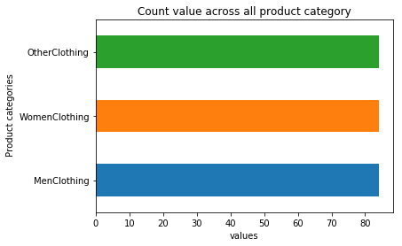

```python
plt.title('Count value across all product category')
plt.xlabel('values')
plt.ylabel(' Product categories')
Train_Data["ProductCategory"].value_counts().plot(kind='barh')
```

From above plot we observed that all the 3 categories of 'ProductCategory' has same count value of 84.

```
Text(0.5,0.98,'Count of sales value in each category')
```

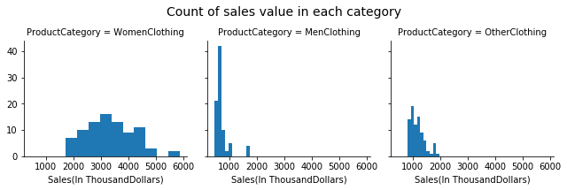

```python
g = sns.FacetGrid(data=Train_Data,col='ProductCategory')
g.map(plt.hist,'Sales(In ThousandDollars)')
g.fig.subplots_adjust(top=0.8)
g.fig.suptitle('Count of sales value in each category', fontsize=14)
```

From above plot we observed that Sales values are more for women clothing compared to other product category.

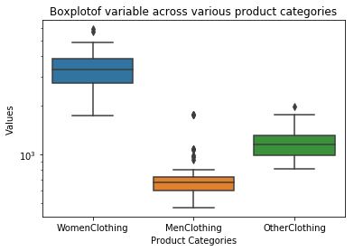

```python
# boxplot of a variable across various product categories
sns.boxplot(x='ProductCategory', y='Sales(In ThousandDollars)', data=Train_Data)
plt.yscale('log')
plt.title('Boxplotof variable across various product categories')
plt.xlabel('Product Categories')
plt.ylabel('Values')
plt.show()
```

So above plot dipicts that the sales of MenClothing are on an average, lower than the other two categories, whereas the sales of other clothing looks much better.Overall, sales of WomenClothing is very much consistent and very high compared to other two product categories.

```
***Based on given problem statement we only have to Predict one year sales of WomenClothing      category products so, we will only use Womenclothing category in our TrainSales data thereby removing other two categories***
```

```python
# Removing the instances of 'MenClothing' and 'OtherClothing' from sales data
SalesTrain_Data = Train_Data.loc[Train_Data.ProductCategory == "WomenClothing" ,:]
```

```python
print("The last 5 rows from the table:")
SalesTrain_Data.tail()
```

```
The last 5 rows from the table:
```

| Date | ProductCategory | Sales(In ThousandDollars) |
| --- | --- | --- |
| 2015-08-01 | WomenClothing | 3897.0 |
| 2015-09-01 | WomenClothing | 3881.0 |
| 2015-10-01 | WomenClothing | 4372.0 |
| 2015-11-01 | WomenClothing | 4401.0 |
| 2015-12-01 | WomenClothing | 5874.0 |

```python
print("The first 10 rows from the table:")
SalesTrain_Data.head(10)
```

```
The first 10 rows from the table:
```

| Date | ProductCategory | Sales(In ThousandDollars) |
| --- | --- | --- |
| 2009-01-01 | WomenClothing | 1755.0 |
| 2009-02-01 | WomenClothing | 1729.0 |
| 2009-03-01 | WomenClothing | 2256.0 |
| 2009-04-01 | WomenClothing | 2662.0 |
| 2009-05-01 | WomenClothing | 2732.0 |
| 2009-06-01 | WomenClothing | 2220.0 |
| 2009-07-01 | WomenClothing | 2164.0 |
| 2009-08-01 | WomenClothing | 2371.0 |
| 2009-09-01 | WomenClothing | 2421.0 |
| 2009-10-01 | WomenClothing | 2579.0 |

Checking the plot for growth of WomenClothing Category sales on yearwise.

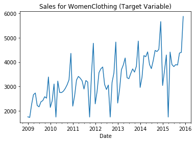

```python
SalesTrain_Data.plot()
plt.title("Sales for WomenClothing (Target Variable)")
plt.legend().remove()
plt.show()
```

# 2) Event_Holidays Data

Checking the Null values

```python
EventHolidays_Data.isnull().sum()
```

```
Event          0
DayCategory    0
dtype: int64
```

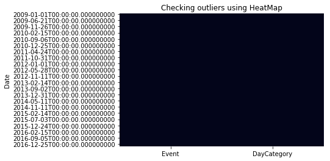

```python
ax = plt.axes()
ax.set_title('Checking outliers using HeatMap')
sns.heatmap(EventHolidays_Data.isnull(), cbar=False, ax=ax)
```

From above plot we visualize no Missing values in Data

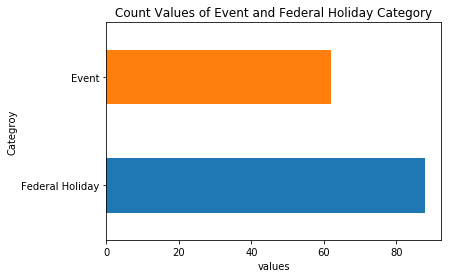

```python
plt.title('Count Values of Event and Federal Holiday Category')
plt.xlabel('values')
plt.ylabel('Categroy')
EventHolidays_Data["DayCategory"].value_counts().plot(kind='barh')
```

From above plot we visualize that Federal Holiday having count value more than 85 is Higher than count value of Event presiding at 62.

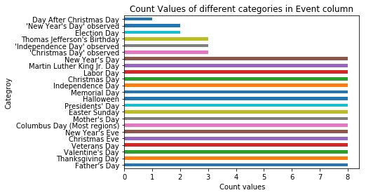

```python
plt.title('Count Values of different categories in Event column')
plt.xlabel(' Count values')
plt.ylabel('Categroy')
EventHolidays_Data["Event"].value_counts().plot(kind='barh')
```

From above plot we observed that 17 out of 23 categories of event columns has same count value 8.

# Resampling the data

Resampling involves changing the frequency of your Data observations. Two types of resampling are: Upsampling and Downsampling. There are perhaps two main reasons why I am interested in resampling your data: 1.Problem Framing: Resampling may be required if data is available at the same frequency that we want to make predictions. 2.Feature Engineering: Resampling can also be used to provide additional structure or insight into the learning problem for supervised learning models. So, Here we Resampled Data with 'M' which point outs to be Month ENd Frequency.

```python
# Converting 'Events' as 1 and 'Federal Holiday' as 4
EventHolidays_Data['DayCategory'] = EventHolidays_Data['DayCategory'].map({'Event':1, 'Federal Holiday':4})
EventHolidays_Data = EventHolidays_Data.resample('M').sum()
EventHolidays_Data.DayCategory.fillna(value= 0, inplace = True)
```

```python
EventHolidays_Data.head(5)
```

| Date | DayCategory |
| --- | --- |
| 2009-01-31 | 8 |
| 2009-02-28 | 5 |
| 2009-03-31 | 0 |
| 2009-04-30 | 1 |
| 2009-05-31 | 5 |

# 3) Macroeconomic Data

Checking Null values in Data

```python
Macroeconomic_Data.isnull().sum()
```

```
Monthly Nominal GDP Index (inMillion$)                               0
Monthly Real GDP Index (inMillion$)                                  0
CPI                                                                  0
PartyInPower                                                         0
unemployment rate                                                    0
CommercialBankInterestRateonCreditCardPlans                          0
Finance Rate on Personal Loans at Commercial Banks, 24 Month Loan    0
Earnings or wages  in dollars per hour                               0
AdvertisingExpenses (in Thousand Dollars)                            0
Cotton Monthly Price - US cents per Pound(lbs)                       0
Change(in%)                                                          0
Average upland planted(million acres)                                0
Average upland harvested(million acres)                              0
yieldperharvested acre                                               0
Production (in  480-lb netweright in million bales)                  0
Mill use  (in  480-lb netweright in million bales)                   0
Exports                                                              0
dtype: int64
```

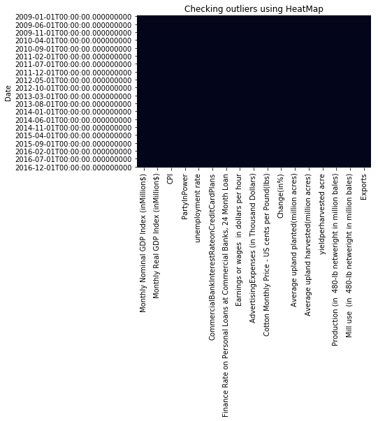

```python
ax = plt.axes()
ax.set_title('Checking outliers using HeatMap')
sns.heatmap(Macroeconomic_Data.isnull(), cbar=False, ax=ax)
```

Now We have to look for categorical and numerical variables in the data

```python
Macroeconomic_Data.dtypes
```

```
Monthly Nominal GDP Index (inMillion$)                               float64
Monthly Real GDP Index (inMillion$)                                  float64
CPI                                                                  float64
PartyInPower                                                          object
unemployment rate                                                    float64
CommercialBankInterestRateonCreditCardPlans                          float64
Finance Rate on Personal Loans at Commercial Banks, 24 Month Loan    float64
Earnings or wages  in dollars per hour                               float64
AdvertisingExpenses (in Thousand Dollars)                             object
Cotton Monthly Price - US cents per Pound(lbs)                       float64
Change(in%)                                                          float64
Average upland planted(million acres)                                float64
Average upland harvested(million acres)                              float64
yieldperharvested acre                                                 int64
Production (in  480-lb netweright in million bales)                  float64
Mill use  (in  480-lb netweright in million bales)                   float64
Exports                                                              float64
dtype: object
```

# Categorical Variable:

```python
print(Macroeconomic_Data["PartyInPower"].value_counts(), "\n")
print("NOTE: The attribute 'PartyInPower' has only one category for all the instances and hence is not useful for the analysis.")

# Droping the column 'PartyInPower'
Macroeconomic_Data.drop('PartyInPower', axis=1,inplace=True)
```

```
Democrats    96
Name: PartyInPower, dtype: int64

NOTE: The attribute 'PartyInPower' has only one category for all the instances and hence is not useful for the analysis.
```

```python
print(Macroeconomic_Data["AdvertisingExpenses (in Thousand Dollars)"].value_counts(), "\n")
print("NOTE: The attribute 'AdvertisingExpenses (in Thousand Dollars)' has 88% of missing values which are denoted as '?'.")

# Droping the column 'AdvertisingExpenses (in Thousand Dollars)'
Macroeconomic_Data.drop('AdvertisingExpenses (in Thousand Dollars)', axis=1,inplace=True)
```

```
?      85
221     1
150     1
208     1
201     1
137     1
200     1
248     1
214     1
165     1
116     1
183     1
Name: AdvertisingExpenses (in Thousand Dollars), dtype: int64

NOTE: The attribute 'AdvertisingExpenses (in Thousand Dollars)' has 88% of missing values which are denoted as '?'.
```

```python
#Checking whether columns are dropped or not
Macroeconomic_Data.head(5)
```

| Date | Monthly Nominal GDP Index (inMillion$) | Monthly Real GDP Index (inMillion$) | CPI | unemployment rate | CommercialBankInterestRateonCreditCardPlans | Finance Rate on Personal Loans at Commercial Banks, 24 Month Loan | Earnings or wages in dollars per hour | Cotton Monthly Price - US cents per Pound(lbs) | Change(in%) | Average upland planted(million acres) | Average upland harvested(million acres) | yieldperharvested acre | Production (in 480-lb netweright in million bales) | Mill use (in 480-lb netweright in million bales) | Exports |
| --- | --- | --- | --- | --- | --- | --- | --- | --- | --- | --- | --- | --- | --- | --- | --- |
| 2009-01-01 | 14421.752895 | 14407.053343 | 233.402 | 7.8 | 12.03 | 11.44 | 22.05 | 57.70 | 4.02 | 9.296 | 7.559 | 799 | 12.589 | 4.17 | 11.550 |
| 2009-02-01 | 14389.200466 | 14366.176571 | 234.663 | 8.3 | 12.97 | 11.05 | 22.22 | 55.21 | -4.32 | 9.296 | 7.559 | 799 | 12.589 | 3.87 | 11.100 |
| 2009-03-01 | 14340.701639 | 14351.786822 | 235.067 | 8.7 | 12.97 | 11.05 | 22.22 | 51.50 | -6.72 | 9.296 | 7.559 | 799 | 12.589 | 3.72 | 11.650 |
| 2009-04-01 | 14326.815525 | 14351.601731 | 235.582 | 9.0 | 12.97 | 11.05 | 22.13 | 56.78 | 10.25 | 9.296 | 7.559 | 787 | 12.400 | 3.62 | 12.225 |
| 2009-05-01 | 14345.904809 | 14368.123959 | 235.975 | 9.4 | 13.32 | 11.25 | 22.04 | 61.95 | 9.11 | 9.297 | 7.400 | 803 | 12.384 | 3.52 | 12.300 |

# Numerical Variables:

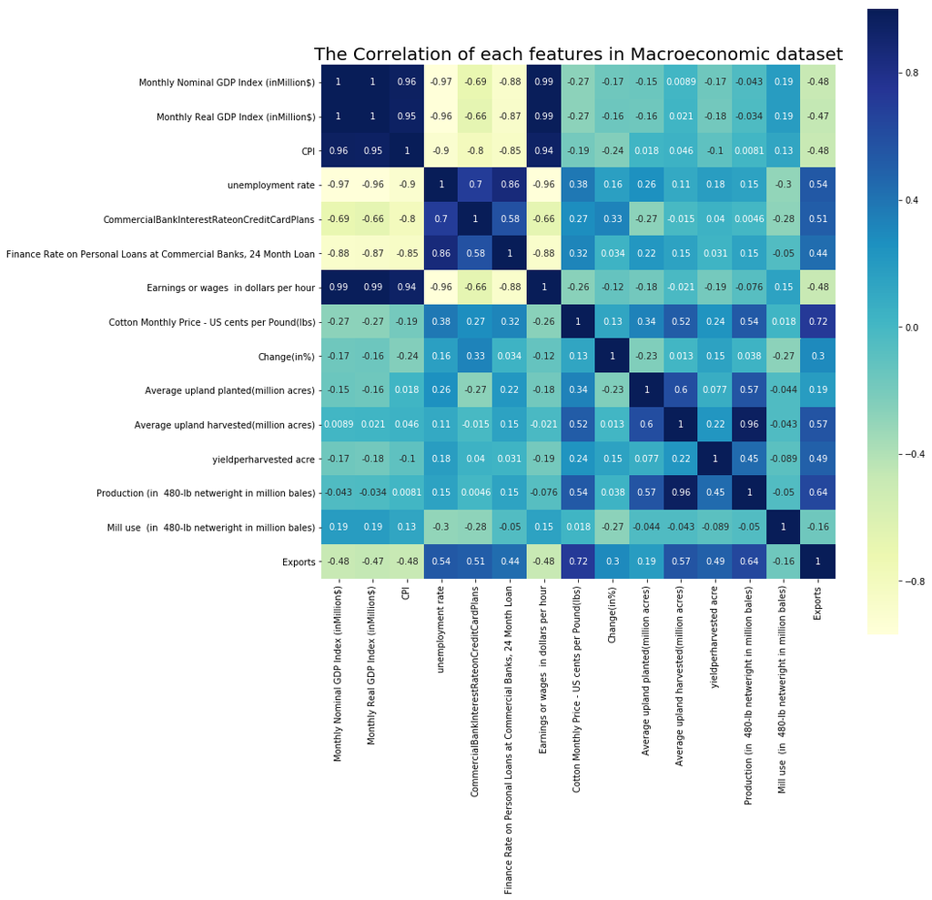

```python
# Calculating the correlation of each variables
correlation = Macroeconomic_Data.corr()

### Ploting the correlation
%matplotlib inline
plt.figure(figsize =(13,13))
sns.heatmap(data= correlation,cmap="YlGnBu", annot =True, square= True)
plt.title('The Correlation of each features in Macroeconomic dataset', fontsize= '20')
plt.show()
```

# 4) Weather Data

Checking Null values and specific datatypes

```python
Weather_Data.dtypes
```

```
Temp high (°C)                 object
Temp avg (°C)                  object
Temp low (°C)                  object
Dew Point high (°C)            object
Dew Point avg (°C)             object
Dew Point low (°C)             object
Humidity (%) high              object
Humidity (%) avg               object
Humidity (%) low               object
Sea Level Press. (hPa) high    object
Sea Level Press. (hPa) avg     object
Sea Level Press. (hPa) low     object
Visibility (km) high           object
Visibility (km) avg            object
Visibility (km) low            object
Wind (km/h) low                object
Wind (km/h) avg                object
Wind (km/h) high               object
Precip. (mm) sum               object
WeatherEvent                   object
dtype: object
```

```python
Weather_Data.describe(include='all')
```

|  | Temp high (°C) | Temp avg (°C) | Temp low (°C) | Dew Point high (°C) | Dew Point avg (°C) | Dew Point low (°C) | Humidity (%) high | Humidity (%) avg | Humidity (%) low | Sea Level Press. (hPa) high | Sea Level Press. (hPa) avg | Sea Level Press. (hPa) low | Visibility (km) high | Visibility (km) avg | Visibility (km) low | Wind (km/h) low | Wind (km/h) avg | Wind (km/h) high | Precip. (mm) sum | WeatherEvent |
| --- | --- | --- | --- | --- | --- | --- | --- | --- | --- | --- | --- | --- | --- | --- | --- | --- | --- | --- | --- | --- |
| count | 2921 | 2921 | 2921 | 2921 | 2921 | 2921 | 2921 | 2921 | 2921 | 2921 | 2921 | 2921 | 2921 | 2921 | 2921 | 2921 | 2921 | 2921 | 2921 | 1014 |
| unique | 51 | 49 | 48 | 50 | 51 | 51 | 66 | 75 | 83 | 51 | 55 | 59 | 7 | 17 | 14 | 31 | 32 | 46 | 178 | 8 |
| top | 28 | 24 | 18 | 18 | 12 | 12 | 100 | 54 | 34 | 1020 | 1016 | 1013 | 16 | 16 | 16 | 21 | 7 | 35 | 0 | Rain |
| freq | 140 | 148 | 135 | 138 | 132 | 116 | 326 | 97 | 94 | 172 | 166 | 174 | 2794 | 1619 | 1274 | 377 | 338 | 229 | 1754 | 685 |

```python
#Counting WeatherEvent columns count value
Weather_Data['WeatherEvent'].value_counts()
```

```
Rain                 685
Fog , Rain           156
Snow                  72
Fog , Snow            39
Rain , Snow           27
Fog , Rain , Snow     22
Fog                   12
Thunderstorm           1
Name: WeatherEvent, dtype: int64
```

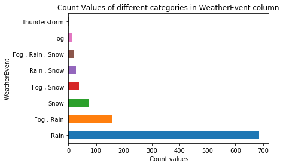

```python
plt.title('Count Values of different categories in WeatherEvent column')
plt.xlabel(' Count values')
plt.ylabel('WeatherEvent')
Weather_Data['WeatherEvent'].value_counts().plot(kind='barh')
```

From above plot we observed that Rain has more count values and so it has most significant role in WeatherEvent

Checking for non-numeric characters in numeric variables

NOTE:- "T" stands for Trace. This is a small amount of precipitation that will wet a raingage but is less than the 0.01 inch measuring limit. Hence converting all the "T" values to 0.01

```python
# Converting the cells that have the value "T" to O.01
Weather_Data[Weather_Data.columns[18]] = Weather_Data[Weather_Data.columns[18]].apply(lambda x: 0.01 if x == 'T' else x)
```

Note:Through data exploration we should notice that certain columns have " - " values which is not possible and need to replace with NA

```python
#Checking data having values '-'.
print((Weather_Data.iloc[:,:] =='-').sum())
```

```
Temp high (°C)                  2
Temp avg (°C)                   2
Temp low (°C)                   2
Dew Point high (°C)             2
Dew Point avg (°C)              2
Dew Point low (°C)              2
Humidity (%) high               2
Humidity (%) avg                2
Humidity (%) low                2
Sea Level Press. (hPa) high    19
Sea Level Press. (hPa) avg     19
Sea Level Press. (hPa) low     19
Visibility (km) high           28
Visibility (km) avg            28
Visibility (km) low            28
Wind (km/h) low                20
Wind (km/h) avg                20
Wind (km/h) high               59
Precip. (mm) sum                1
WeatherEvent                    0
dtype: int64
```

```python
# Converting all cells that have the value "-" to NaN
Weather_Data = Weather_Data.applymap(lambda x: np.nan if x == '-' else x)
```

```python
Weather_Data.head(5)
```

| Date | Temp high (°C) | Temp avg (°C) | Temp low (°C) | Dew Point high (°C) | Dew Point avg (°C) | Dew Point low (°C) | Humidity (%) high | Humidity (%) avg | Humidity (%) low | Sea Level Press. (hPa) high | Sea Level Press. (hPa) avg | Sea Level Press. (hPa) low | Visibility (km) high | Visibility (km) avg | Visibility (km) low | Wind (km/h) low | Wind (km/h) avg | Wind (km/h) high | Precip. (mm) sum | WeatherEvent |
| --- | --- | --- | --- | --- | --- | --- | --- | --- | --- | --- | --- | --- | --- | --- | --- | --- | --- | --- | --- | --- |
| 2009-01-01 | -3.0 | -6.0 | -9.0 | -16.0 | -17.0 | -19.0 | 54.0 | 43.0 | 32.0 | 1025.0 | 1023.0 | 1015.0 | 16.0 | 16.0 | 16.0 | 37.0 | 18.0 | 60.0 | 0.00 | NaN |
| 2009-01-02 | 1.0 | -2.0 | -5.0 | -3.0 | -7.0 | -17.0 | 78.0 | 57.0 | 36.0 | 1022.0 | 1012.0 | 1007.0 | 16.0 | 13.0 | 2.0 | 27.0 | 10.0 | 48.0 | 0.01 | Snow |
| 2009-01-03 | 3.0 | 1.0 | -2.0 | -5.0 | -9.0 | -13.0 | 72.0 | 54.0 | 35.0 | 1018.0 | 1015.0 | 1008.0 | 16.0 | 16.0 | 16.0 | 27.0 | 16.0 | 42.0 | 0.01 | NaN |
| 2009-01-04 | 6.0 | 1.0 | -4.0 | -10.0 | -12.0 | -13.0 | 55.0 | 42.0 | 29.0 | 1020.0 | 1017.0 | 1015.0 | 16.0 | 16.0 | 16.0 | 32.0 | 12.0 | 40.0 | 0.00 | NaN |
| 2009-01-05 | 6.0 | 5.0 | 3.0 | -1.0 | -5.0 | -16.0 | 62.0 | 48.0 | 33.0 | 1016.0 | 1014.0 | 1013.0 | 16.0 | 16.0 | 16.0 | 23.0 | 11.0 | 34.0 | 0.01 | NaN |

```python
# Replacing the missing values in 'WeatherEvent' column to "NA"
Weather_Data.WeatherEvent.fillna(value="NotApplicable", inplace=True)

# Droping the rows having all columns as NaN
Weather_Data = Weather_Data[~Weather_Data["Temp high (°C)"].isnull()]
```